# Cryptocurrency Web Trends and Market Price

Alfredo Muñoz Gutierrez

2022-11-12

## Introduction

On this project I analyzed the relation between the market price of the top cryptocurrencys and the Web searches for crypto terms. In order to do the analysis I got price data of **Bitcoin and Ethereum** from Yahoo Finance website and **Google trends** data about keywords related with the crypto ecosystem. The main goal of this analysis was find out if there is a positive correlation between cryptocurrencys price and Google searches of crypto-related words, in case it is true, if an increase in **cryptocurrencys price** is related to a **high volume of searches** in the web for crypto terms or if the increase of web searches influence the cryptocurrencys price. Other objectives were spot the locations with most interest in the crypto terms as well as if there are any correlation between Bitcoin and Ethereum price.

### Objetives

#### Answer the following questions:

1. ¿What is the relation between cryptocurrencys market price and Google trends of crypto terms? ¿Is one variable causing the other to change?
2. ¿Wich locations have most interest in search for crypto terms?
3. ¿Is there a correlation between Bitcoin and Ethereum price?

## Data Collection, Cleaning and Exploration

The first step was to load the librarys `gtrendsR` to get the Google trends data and `tidyverse` to clean, tidy and plot the data in order to answer the analysis’ questions. The market price data was imported from csv files.

```r
library(gtrendsR)
library(tidyverse)
setwd("~/R/Codecademy-Capstone Project Exploring Google Trends Data/Data")
#import Bitcoin and Ethereum price data to data frames
btc_data <- read_csv("BTC-USD.csv",show_col_types = FALSE)
eth_data <- read_csv("ETH-USD.csv", show_col_types = FALSE)
```

Then the `btc_data` dataframe was cleaned and the Bitcoin and Ethereum market prices were plotted (data from the last 5 years).

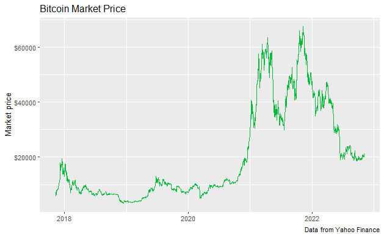

```r
#Convert date column to date type
btc_data <- btc_data %>%
  mutate(Date = as.Date(Date,"%d/%m/%Y"))

#Plot Bitcoin price from the last 5 years
ggplot(btc_data) + geom_line(aes(Date,Close), color="#00BA38") +
  labs(title="Bitcoin Market Price",
       caption="Data from Yahoo Finance", x=NULL, y="Market price") +
  scale_y_continuous(label = function(x) paste0('$', x))
```

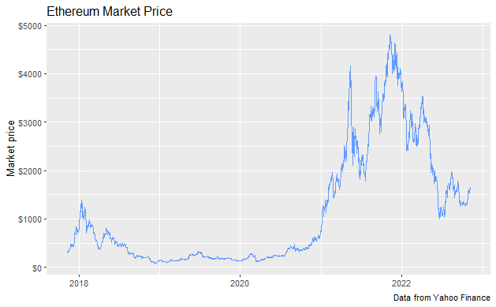

```r
#Plot Ethereum price from the last 5 years
ggplot(eth_data) + geom_line(aes(Date,Close), color="#619CFF") +
  labs(title="Ethereum Market Price",
       caption="Data from Yahoo Finance", x=NULL, y="Market price") +
  scale_y_continuous(label = function(x) paste0('$', x))
```

With the `gtrends` function the popularity over time for the crypto words was gotten and after cleaning the data I plotted the results for each keyword.

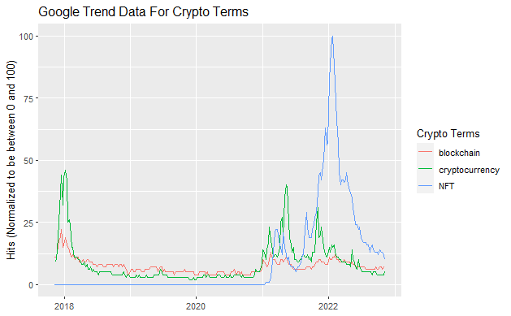

```r
#Get Google trends data about crypto keywords from the last 5 years
crypto_trends <- gtrends(c("cryptocurrency", "blockchain", "NFT"))
crypto_trends_over_time <- crypto_trends$interest_over_time

#Change the "<1" values in "hits" column to 0 and convert to numeric data type
crypto_trends_over_time$hits[crypto_trends_over_time$hits == "<1"] <- "0"
crypto_trends_over_time <- crypto_trends_over_time %>%
  mutate(hits=as.numeric(hits))

#Plot trends linear graph
ggplot(crypto_trends_over_time, aes(date, hits, color=keyword)) +
  geom_line() +
  scale_color_discrete(name = "Crypto Terms") +
  labs(title = "Google Trend Data For Crypto Terms",
       x=NULL, y = "Hits (Normalized to be between 0 and 100)")
```

## Crypto Popularity in the World

In order to find what are the places with most interest in search for crypto terms I use the *interest_by_country* dataframe from the Google trends data wich has the popularity data for each country. Then I order and filter the dataset to get the top 10 countries with most interest in “cryptocurrency” and “NFT” keywords.

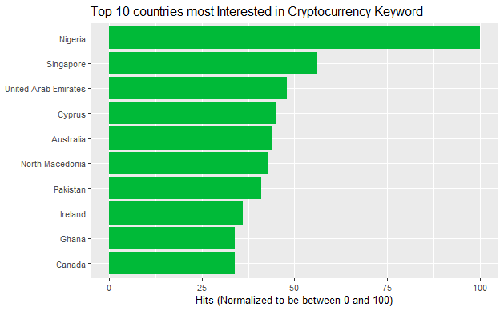

```r
#Get top 10 countries with most "cryptocurrency" searches popularity
crypto_trends_countries <- crypto_trends$interest_by_country
cryptocurrency_countries <- crypto_trends_countries %>%
  filter(keyword=="cryptocurrency") %>%
  arrange(-hits) %>%
  head(10)

#Plot top 10 countries for "cryptocurrency"
ggplot(cryptocurrency_countries, aes(x=hits,
      y=forcats::fct_reorder(location, hits))) + geom_col(fill="#00BA38") +
  labs(title="Top 10 countries most Interested in Cryptocurrency Keyword",
       x= "Hits (Normalized to be between 0 and 100)" , y=NULL)
```

Besides being a underdeveloped country **Nigeria** is the place with most interest in search “cryptocurrency” in Google then this could be a opportunity for crypto exchanges or another crypto-related business to approach and expand to this market.

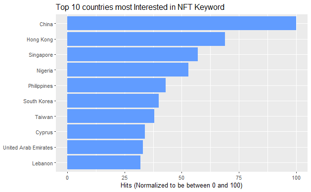

```r
#Get top 10 countries with most "NFT" searches popularity
NFT_countries <- crypto_trends_countries %>%
  filter(keyword=="NFT") %>%
  arrange(-hits) %>%
  head(10)

#Plot 10 countries for "NFT"
ggplot(NFT_countries, aes(x=hits,
      y=forcats::fct_reorder(location, hits))) + geom_col(fill="#619CFF") +
  labs(title="Top 10 countries most Interested in NFT Keyword",
       x= "Hits (Normalized to be between 0 and 100)" , y=NULL)
```

## Price Data vs Trends Data

To be able to answer the main question of the analysis I combine the market price and Google trends data adjusting the scale to have a good view of the correlation between the variables. Since Bitcoin is the top cryptocurrency in the market and the most popular I compare its price with the popularity of “cryptocurrency” keyword and due to Ethereum blockchain is the most used to buy and sell NFTs I compare the Ethereum price with the “NFT” keyword.

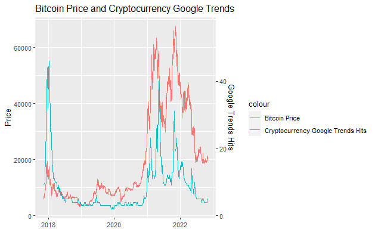

```r
#Plot price and trends together for Bitcoin and cryptocurrency
ggplot() + geom_line(btc_data, mapping = aes(Date, Close,
  color = "Bitcoin Price")) + geom_line(filter(crypto_trends_over_time,
  keyword == "cryptocurrency"), mapping = aes(as.Date(date), hits*1200,
  color = "Cryptocurrency Google Trends Hits")) +
  scale_y_continuous(name = "Price", sec.axis = sec_axis(~./1200,
  name="Google Trends Hits")) +
  labs(title = "Bitcoin Price and Cryptocurrency Google Trends", x=NULL)
```

We can see that in some time periods there is acorrelation between Bitcoin price and “cryptocurrency” web searches since when there is a increase in one the other increase too but this not happens always. In early 2021 there is a suddenly increase in both variables then the market price kept increasing while the “cryptocurrency” popularity decrease but when the market price reaches a peak the web searches suddenly increase reaching a peak at the same time.

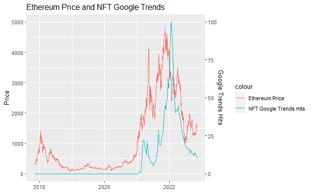

```r
#Plot price and trends together for Ethereum and NFT
ggplot() + geom_line(eth_data, mapping = aes(Date, Close,
  color = "Ethereum Price")) + geom_line(filter(crypto_trends_over_time,
  keyword == "NFT"), mapping = aes(as.Date(date), hits*50,
  color = "NFT Google Trends Hits")) +
  scale_y_continuous(name = "Price", sec.axis = sec_axis(~./50,
  name="Google Trends Hits")) +
  labs(title = "Ethereum Price and NFT Google Trends", x=NULL)
```

## Price correlation

Bitcoin and Ethereum seems to be very dependent on the crypto popularity and they also look like them prices have a similar trend. I made a scatter plot of the prices for both cryptocurrencys with a trend line and the calculated linear regression to see if there is a strong correlation.

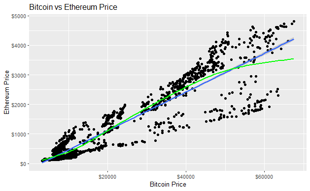

```r
#Merge Bitcoin and Ethereum price
crypto_price <- btc_data %>%
  inner_join(eth_data, by="Date") %>%
  select(Date,Close.x, Close.y )

#Plot Bitcoin and Ethereum price correlation
ggplot(crypto_price, aes(Close.x,Close.y)) + geom_point() +
  geom_smooth(method= "lm") +
  geom_smooth(se = FALSE, color = "green") +
  labs(title="Bitcoin vs Ethereum Price",
       x="Bitcoin Price", y="Ethereum Price") +
  scale_y_continuous(label = function(x) paste0('$', x)) +
  scale_x_continuous(label = function(x) paste0("$", x))
```

It looks like there are a positive correlation between the Bitcoin and Ethereum prices but there some points that does not have the same trend making the trend line differ from the trend line obtain from the linear regression method. Possibly if other variables as the date were included in the model better results could be achieved.